# Multivariate models for the BPA/BPS vs growth outcomes

TO DISCUSS:

- Binarise BPS? If yes in which cat to include [LOD, LOQ]?
- How to deal with sex?
- I don’t have a variable to measure time between dob and hc measure (cf note hereafter)
- Discuss what to present in the next version of this document and how to present it

Note on head circumference: data currently presented is data from carnet de santé and is measured the day of the exam by the clinic doctors. Another measure is perfomed approx 3 days later for sepages. I don’t have this data yet and according to Sarah there might be up to 50% missing (19/11/19).

TO DO:

- Ultrasound outcomes
- Get day 3 HC measure + check Ns and re-run analysis + copmpare birth day measure with D3 measure

# 1 Intro

This document is a first draft to show the model outputs of the analysis “exposure to BPA/BPS during pregnancy vs growth outcomes”.

First I plot the estimates + 95%CI of the adjusted effect of exposure at T1 and T3 (separate models) vs the birth growth outcomes.

For BPS I presented the exposed/unexposed model for ease of interpretation and due to the relatively small N of samples [LOD, LOQ].

After these plots I present the full model outputs and the model residual qqplots.

Finally in the sensitivity analysis I present the BPS divided in 3 categories and the interactions with sex (alongside the main model).

# 2 Main results

## 2.1 BPA

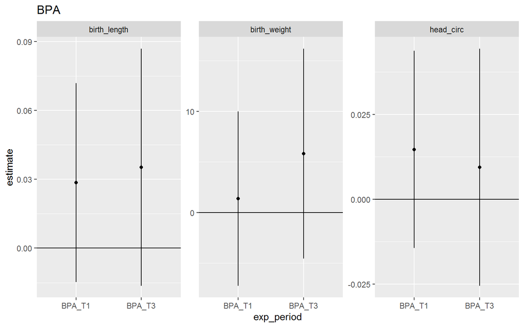

## 2.2 BPS

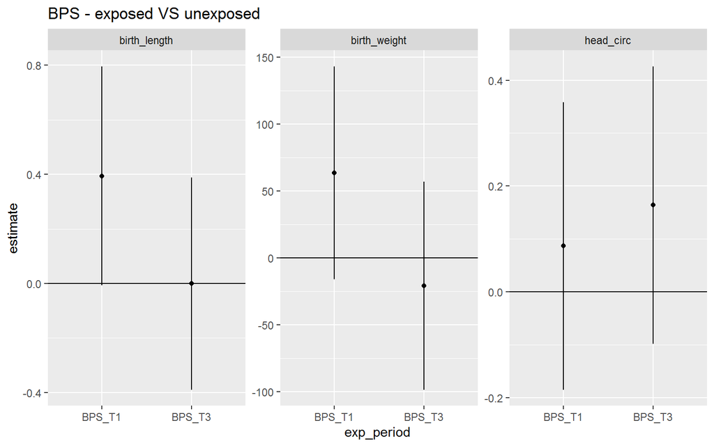

# 3 Main results with interaction on sex

Here I show betas from the interaction model (standardised by sd division +/- 1.96) alongside the betas from the reference model from part 1.

### 3.0.1 BPA

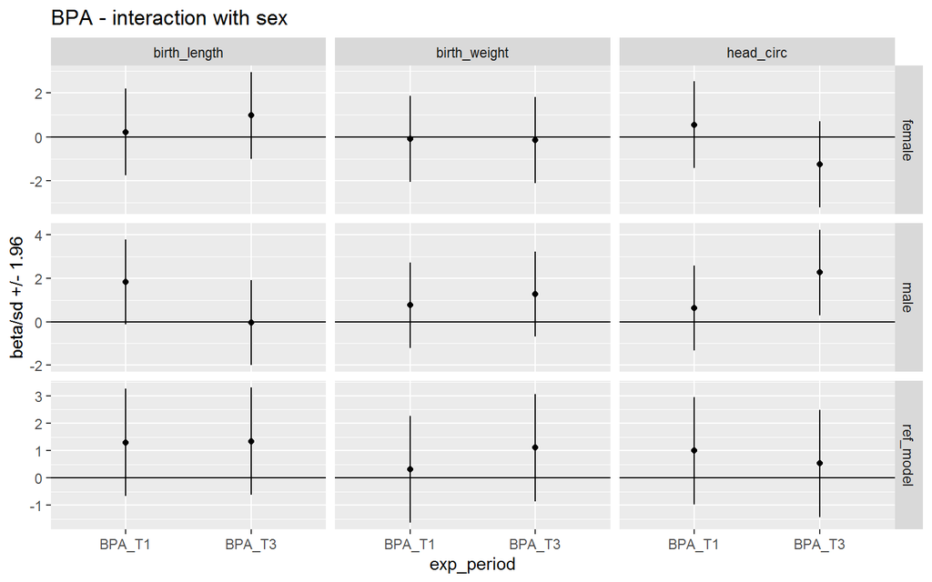

### 3.0.2 BPS

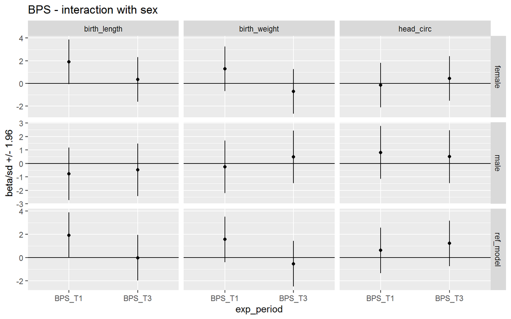

# 4 Main model outputs

## 4.1 BPA

```
## [1] "*******************birth_length*******************"
## [2] "*******************BPA_T1*******************"
##
## Call:
## lm(formula = outcome_val ~ exp_val + child_sex + mom_age + mom_weight +
##     mom_height + gestational_age + I(gestational_age^2) + mom_edu +
##     parity + smoke_high_t2, data = .x)
##
## Residuals:
##     Min      1Q  Median      3Q     Max
## -5.2513 -1.1718  0.0451  1.0365  6.2358
##
## Coefficients:
##                              Estimate Std. Error t value Pr(>|t|)
## (Intercept)                -91.326932  26.035105  -3.508 0.000503 ***
## exp_val                      0.028539   0.022025   1.296 0.195807
## child_sexmale                0.996705   0.178847   5.573  4.6e-08 ***
## mom_age                      0.055330   0.024256   2.281 0.023069 *
## mom_weight                   0.004383   0.008679   0.505 0.613793
## mom_height                   0.078366   0.015109   5.187  3.4e-07 ***
## gestational_age              5.824431   1.356265   4.294  2.2e-05 ***
## I(gestational_age^2)        -0.066413   0.017820  -3.727 0.000222 ***
## mom_eduBac +3-4             -0.621008   0.274285  -2.264 0.024100 *
## mom_edu>=Bac +5             -0.348188   0.247627  -1.406 0.160466
## paritySecond child or more   0.082831   0.187293   0.442 0.658541
## smoke_high_t2               -1.479744   0.575621  -2.571 0.010509 *
## ---
## Signif. codes:  0 '***' 0.001 '**' 0.01 '*' 0.05 '.' 0.1 ' ' 1
##
## Residual standard error: 1.788 on 402 degrees of freedom
##   (70 observations deleted due to missingness)
## Multiple R-squared:  0.3933, Adjusted R-squared:  0.3767
## F-statistic: 23.69 on 11 and 402 DF,  p-value: < 2.2e-16
##
## [1] "*******************birth_length*******************"
## [2] "*******************BPA_T3*******************"
##
## Call:
## lm(formula = outcome_val ~ exp_val + child_sex + mom_age + mom_weight +
##     mom_height + gestational_age + I(gestational_age^2) + mom_edu +
```

[output cut: 148 more lines]

```
## mom_weight                  0.012530   0.005912   2.119   0.0347 *
## mom_height                  0.018381   0.010345   1.777   0.0764 .
## gestational_age             0.715492   1.511537   0.473   0.6362
## I(gestational_age^2)       -0.004151   0.019573  -0.212   0.8321
## mom_eduBac +3-4            -0.210656   0.187655  -1.123   0.2623
## mom_edu>=Bac +5             0.078938   0.167813   0.470   0.6383
## paritySecond child or more  0.099789   0.128029   0.779   0.4362
## smoke_high_t2              -0.323362   0.388301  -0.833   0.4055
## ---
## Signif. codes:  0 '***' 0.001 '**' 0.01 '*' 0.05 '.' 0.1 ' ' 1
##
## Residual standard error: 1.206 on 391 degrees of freedom
##   (81 observations deleted due to missingness)
## Multiple R-squared:  0.233,  Adjusted R-squared:  0.2114
## F-statistic:  10.8 on 11 and 391 DF,  p-value: < 2.2e-16
```

[output not shown]

## 4.2 BPS

```
## [1] "*******************birth_length*******************"
## [2] "*******************BPS_T1*******************"
##
## Call:
## lm(formula = outcome_val ~ exp_val2 + child_sex + mom_age + mom_weight +
##     mom_height + gestational_age + I(gestational_age^2) + mom_edu +
##     parity + smoke_high_t2, data = .x)
##
## Residuals:
##     Min      1Q  Median      3Q     Max
## -5.5603 -1.1645  0.0026  1.0257  6.4908
##
## Coefficients:
##                              Estimate Std. Error t value Pr(>|t|)
## (Intercept)                -93.699143  25.945118  -3.611 0.000343 ***
## exp_val21                    0.393883   0.204286   1.928 0.054547 .
## child_sexmale                0.993238   0.178098   5.577 4.50e-08 ***
## mom_age                      0.058622   0.024284   2.414 0.016221 *
## mom_weight                   0.003963   0.008650   0.458 0.647132
## mom_height                   0.078609   0.015072   5.216 2.94e-07 ***
## gestational_age              5.953022   1.350905   4.407 1.35e-05 ***
## I(gestational_age^2)        -0.068235   0.017747  -3.845 0.000140 ***
## mom_eduBac +3-4             -0.632520   0.273710  -2.311 0.021343 *
## mom_edu>=Bac +5             -0.342258   0.246506  -1.388 0.165774
## paritySecond child or more   0.062403   0.187371   0.333 0.739272
## smoke_high_t2               -1.392945   0.576673  -2.415 0.016160 *
## ---
## Signif. codes:  0 '***' 0.001 '**' 0.01 '*' 0.05 '.' 0.1 ' ' 1
##
## Residual standard error: 1.784 on 402 degrees of freedom
##   (70 observations deleted due to missingness)
## Multiple R-squared:  0.3963, Adjusted R-squared:  0.3798
## F-statistic: 23.99 on 11 and 402 DF,  p-value: < 2.2e-16
##
## [1] "*******************birth_length*******************"
## [2] "*******************BPS_T3*******************"
##
## Call:
## lm(formula = outcome_val ~ exp_val2 + child_sex + mom_age + mom_weight +
##     mom_height + gestational_age + I(gestational_age^2) + mom_edu +
```

[output cut: 148 more lines]

```
## mom_weight                  0.012570   0.005897   2.132   0.0337 *
## mom_height                  0.018195   0.010327   1.762   0.0789 .
## gestational_age             0.632944   1.508079   0.420   0.6749
## I(gestational_age^2)       -0.003145   0.019528  -0.161   0.8722
## mom_eduBac +3-4            -0.205144   0.187412  -1.095   0.2744
## mom_edu>=Bac +5             0.080618   0.167533   0.481   0.6306
## paritySecond child or more  0.090819   0.127867   0.710   0.4780
## smoke_high_t2              -0.325606   0.387628  -0.840   0.4014
## ---
## Signif. codes:  0 '***' 0.001 '**' 0.01 '*' 0.05 '.' 0.1 ' ' 1
##
## Residual standard error: 1.204 on 391 degrees of freedom
##   (81 observations deleted due to missingness)
## Multiple R-squared:  0.2354, Adjusted R-squared:  0.2139
## F-statistic: 10.94 on 11 and 391 DF,  p-value: < 2.2e-16
```

[output not shown]